# **Predicting Voter Turnout and Swing State Trends based on Voter Demographic Changes Overtime (1980 - 2024)**

## **Fall 2024 Data Science Project**

Dhruvi Patel (118878676), Nandini Ramachandran (118556574), Kamala Sreepada (119309087)

## **A: Introduction**

Elections in the United States serve as a lens through which we can observe the political, social, and demographic undercurrents shaping the nation. By analyzing general election trends over time, we uncover patterns in voter turnout, partisan dynamics, and demographic shifts.\ We aim to answer several pressing questions through our analysis like:

- How do political affiliations influence voter turnout?
- Which demographic groups (e.g., race, gender) are more likely to participate in elections?
- What are the unique voting patterns in swing states over time?

These insights provide a comprehensive view of how different factors such as political affiliations, economic conditions, and public sentiment contribute to electoral outcomes.

Within this broader context, we turned our focus to swing states, the battlegrounds where elections are often decided. Unlike solidly blue or red states, swing states exhibit dynamic voting patterns, making them critical to understanding shifts in the electorate. Analyzing data from swing states such as Arizona, Georgia, Michigan, and Pennsylvania from 1980 to 2020 allowed us to delve deeper into the interplay between voter turnout, party alignment, and demographic trends. These states allow us to explore pivotal questions about the factors influencing electoral outcomes and to anticipate trends for future elections, including the recently conducted 2024 presidential race.

# **B: Data Sources**

1. **2020 Popular Vote Tracker**

   **Source**: Cook Political Report\ **Description**: Comprehensive data on the popular vote across all states, with an emphasis on swing state trends.\ **Purpose**: To study the importance of swing states in determining election outcomes.\ **Citation**: \ Cook Political Report. (n.d.). 2020 Popular Vote Tracker | Cook Political Report. https://www.cookpolitical.com/vote-tracker/2020/electoral-college
1. **Census Data on Voter Demographics**

   **Source**: U.S. Census Bureau\ **Description**: This dataset provides detailed information on voter turnout, disaggregated by race, gender, and age, for the 2020 election.\ **Purpose**: To analyze demographic factors influencing voter turnout.\ **Citation**: \ US Census Bureau. (2021, November 22). Voting and registration tables. Census.gov. https://www.census.gov/topics/public-sector/voting/data/tables.2020.List_1863097513.html#list-tab-List_1863097513
1. **Historical Election Results**

   **Source**: American Presidency Project\ **Description**: Historical data on presidential election outcomes from 1968 to 2020, including popular and electoral vote distributions.\ **Purpose**: To track trends in swing states and assess shifts in political affiliations over time. \ **Citation**: \ Election listing | The American Presidency Project. (n.d.). https://www.presidency.ucsb.edu/statistics/elections

```python
from google.colab import drive
drive.mount('/content/drive/')
```

```python
import pandas as pd
import matplotlib.pyplot as plt
import seaborn as sb
import scipy.stats as stats
from scipy.stats import chi2_contingency
import statsmodels.api as sm
```

## **C: Data Exploration and Summary Statistics**

**EXPERIMENT 1**

```
F_onewayResult(statistic=428.92300895771, pvalue=9.887279239100242e-67)

Tukey's HSD Test Results:
        Multiple Comparison of Means - Tukey HSD, FWER=0.05
===================================================================
    group1        group2    meandiff p-adj   lower   upper   reject
-------------------------------------------------------------------
  dem_percent other_percent -46.1368    0.0 -50.497 -41.7767   True
  dem_percent   rep_percent   1.2421 0.7791 -3.1181   5.6023  False
other_percent   rep_percent  47.3789    0.0 43.0188  51.7391   True
-------------------------------------------------------------------
```

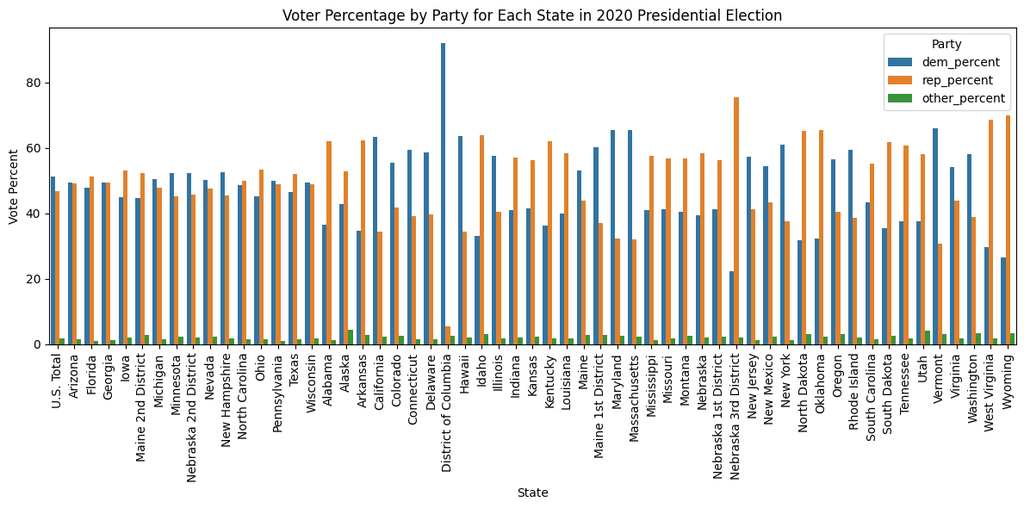

```python
voter_turnout_df = pd.read_csv('/content/drive/MyDrive/320_project_data/2020_voter_tracking.csv')

#remove 15 key battlegrounds and non battleground rows from table
voter_turnout_df = voter_turnout_df[(voter_turnout_df['state'] != '15 Key Battlegrounds') &
                                    (voter_turnout_df['state'] != 'Non-Battlegrounds')]

# Convert percentages from strings to numbers by removing percents and changing from object to numeric
voter_turnout_df['dem_percent'] = pd.to_numeric(voter_turnout_df['dem_percent'].str.replace('%', '').str.strip(), errors='coerce')
voter_turnout_df['rep_percent'] = pd.to_numeric(voter_turnout_df['rep_percent'].str.replace('%', '').str.strip(), errors='coerce')
voter_turnout_df['other_percent'] = pd.to_numeric(voter_turnout_df['other_percent'].str.replace('%', '').str.strip(), errors='coerce')

# drop any rows that may not have dem, rep, or other percent
voter_turnout_df = voter_turnout_df.dropna(subset=['dem_percent', 'rep_percent', 'other_percent'])

#use anova test to compare average voting percentage per party per state and find statistical significance of these factors
anova_result = stats.f_oneway(
    voter_turnout_df['dem_percent'],
    voter_turnout_df['rep_percent'],
    voter_turnout_df['other_percent']
)
print(anova_result)

#plotting bar graph to display voting percent per party per state during the 2020 presidential election
plt.figure(figsize=(12, 6))

#melt data to make it easier to plot in bar graph format
melt_data = voter_turnout_df.melt(id_vars='state', value_vars=['dem_percent', 'rep_percent', 'other_percent'],
                                      var_name='Party', value_name='Vote_Percent')
sb.barplot(data=melt_data, x='state', y='Vote_Percent', hue='Party')

#Use Post Hoc Test to find specific group statistically different
tukey_result = sm.stats.multicomp.pairwise_tukeyhsd(endog=melt_data['Vote_Percent'], groups=melt_data['Party'], alpha=0.05)

print("\nTukey's HSD Test Results:")
print(tukey_result)

#labels and legend
plt.xticks(rotation=90)
plt.title('Voter Percentage by Party for Each State in 2020 Presidential Election')
plt.ylabel('Vote Percent')
plt.xlabel('State')
plt.legend(title='Party')
plt.tight_layout()
plt.show()
```

In analyzing the voter turnout dataset, the null hypothesis states there is no significant difference in the mean percentages of votes among Democratic, Republican, and Other parties across different states during the 2020 presidential election. The alternative hypothesis states that at least one party's mean voter percentage is significantly different from the others. This will help identify whether political affiliations influenced voter turnout in states during the 2020 presidential election. An Anova test and Post Hoc test was used as the mean percentages of three groups (Democratic, Republican, and Other). An Anova test is best when comparing the statistical difference between groups which was necessary in this case to compare Democratic, Republican, and other voter turnout. The Post Hoc Test is useful to determine the specific group is statistically different from the others.

Our alpha to test significance is set to 5% meaning alpha = 0.05. The p-value from the anova test was 9.887279239100242e-67 which is close to 0 and less than 0.05, meaning we reject the null hypothesis and there is at least one party's voter percentage is significantly different from the other party. Based on the post-hoc test conducted, the Democratic and Other parties show significant differences in their voting percentages, while there is no significant difference between the Democratic and Republican percentages. This may mean that both Democratic and Republican parties are highly polarized or different during this election cycle to attract specific voters. The significance between Democratic and Other parties may display that the Other parties may be attracting a portion of voters that may normally support the Democrat party.

Some of the main characteristics of the data set include total votes for each party, voting percents for each party, voter changes, and 2016 voter margins, and 2016 total votes. However, this analysis is mainly about voter percentage per party in each state during the 2020 presidential election. Overall, I believe the main features represented are the party voter percentages. In this case, I dont believe a feature was over represented because data did not need to be dropped or replaced. Based on the data, some features that may be highly correlated are state and voter party percentage, as many southern and midwestern states are likely to vote republican while north-eastern states are more likely to vote Democratic. There are two main outliers displayed in the bar graph which is the District of Columbia (DC) and Nebraska. The Democratic voter's support in DC is extremely high in comparision to the other states, including states that are considered blue. Additionally, Nebraska's Republican voter's support is somewhat high compared to other stated considered red.

**EXPERIMENT 2**

```python
dem_df = pd.read_csv('/content/drive/MyDrive/320_project_data/dem_data.csv')
dem_df
```

|  | STATE | Sex, Race, and Hispanic-Origin | Total population | Total citizen population | Total registered | Percent registered\n (Total) | Margin of error 1 | Percent registered\n (Citizen) | Margin of error 1.1 | Total voted | Percent voted\n (Total) | Margin of error 1.2 | Percent voted\n (Citizen) | Margin of error 1.3 |
| --- | --- | --- | --- | --- | --- | --- | --- | --- | --- | --- | --- | --- | --- | --- |
| 0 | US | Total | 252,274 | 231,593 | 168,308 | 66.7 | 0.4 | 72.7 | 0.4 | 154,628 | 61.3 | 0.4 | 66.8 | 0.4 |
| 1 | US | Male | 121,870 | 111,485 | 79,340 | 65.1 | 0.5 | 71.2 | 0.5 | 72,474 | 59.5 | 0.5 | 65 | 0.5 |
| 2 | US | Female | 130,404 | 120,108 | 88,968 | 68.2 | 0.5 | 74.1 | 0.5 | 82,154 | 63 | 0.5 | 68.4 | 0.5 |
| 3 | US | White alone | 195,227 | 181,891 | 134,889 | 69.1 | 0.4 | 74.2 | 0.4 | 124,301 | 63.7 | 0.4 | 68.3 | 0.4 |
| 4 | US | White non-Hispanic alone | 157,442 | 154,827 | 118,389 | 75.2 | 0.4 | 76.5 | 0.4 | 109,830 | 69.8 | 0.4 | 70.9 | 0.4 |
| ... | ... | ... | ... | ... | ... | ... | ... | ... | ... | ... | ... | ... | ... | ... |
| 567 | WYOMING | Asian alone | 2 | - | - | B | B | B | B | - | B | B | B | B |
| 568 | WYOMING | Hispanic (of any race) | 40 | 38 | 23 | B | B | B | B | 21 | B | B | B | B |
| 569 | WYOMING | White alone or in combination | 422 | 416 | 290 | 68.6 | 3.5 | 69.6 | 3.5 | 273 | 64.7 | 3.6 | 65.7 | 3.6 |
| 570 | WYOMING | Black alone or in combination | 4 | 3 | 3 | B | B | B | B | 3 | B | B | B | B |
| 571 | WYOMING | Asian alone or in combination | 4 | 2 | 2 | B | B | B | B | 2 | B | B | B | B |

572 rows × 14 columns

```
Summary Statistics for White Voters:
count    36.000000
mean     65.566667
std       6.027034
min      54.300000
25%      61.475000
50%      65.000000
75%      69.600000
max      80.300000
Name: Percent voted\n (Total), dtype: float64

Summary Statistics for Black Voters:
count    36.000000
mean     57.069444
std       9.334692
min      29.000000
25%      51.750000
50%      57.650000
75%      62.000000
max      76.700000
Name: Percent voted\n (Total), dtype: float64

T-statistic: 4.588410412161294

P-value: 2.3356701099655224e-05

Outliers:
                   STATE Sex, Race, and Hispanic-Origin  \
7               ARKANSAS                    Black alone
16  DISTRICT OF COLUMBIA                    White alone
31                  IOWA                    Black alone
43         MASSACHUSETTS                    Black alone
99             WISCONSIN                    Black alone

   Percent voted\n (Total)
7                     43.3
16                    80.3
31                    42.6
43                      29
99                    43.5
```

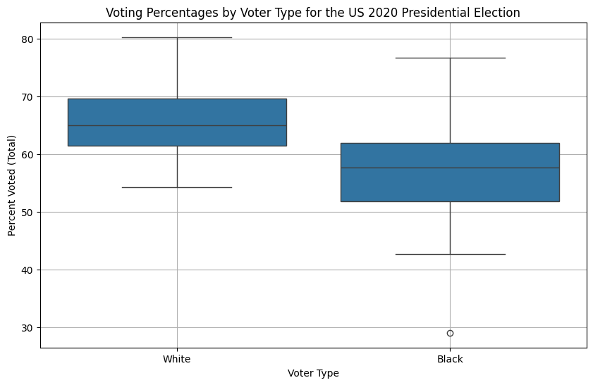

```python
filtered_df = dem_df[['STATE', 'Sex, Race, and Hispanic-Origin', 'Percent voted\n (Total)']]
filtered_df = filtered_df[filtered_df['Sex, Race, and Hispanic-Origin'].isin(['Black alone', 'White alone'])]
filtered_df = filtered_df.iloc[2:]
filtered_df = filtered_df.reset_index(drop=True)
filtered_df = filtered_df[pd.to_numeric(filtered_df['Percent voted\n (Total)'], errors='coerce').notna()]
filtered_df = filtered_df.groupby('STATE').filter(lambda x: len(x) > 1)

white_voters = filtered_df[filtered_df['Sex, Race, and Hispanic-Origin'] == 'White alone']['Percent voted\n (Total)'].astype(float)
black_voters = filtered_df[filtered_df['Sex, Race, and Hispanic-Origin'] == 'Black alone']['Percent voted\n (Total)'].astype(float)

t_stat, p_value = stats.ttest_ind(white_voters, black_voters, equal_var=False)

# Print summary statistics
print("Summary Statistics for White Voters:")
print(white_voters.describe())
print("\nSummary Statistics for Black Voters:")
print(black_voters.describe())

print(f"\nT-statistic: {t_stat}")
print(f"\nP-value: {p_value}")


voter_data = pd.DataFrame({
    'Voter Type': ['White'] * len(white_voters) + ['Black'] * len(black_voters),
    'Percent Voted': pd.concat([white_voters, black_voters])
})

print(f"\nOutliers:")
z_scores = stats.zscore(filtered_df['Percent voted\n (Total)'].astype(float))
outliers = filtered_df[abs(z_scores) > 2]
print(outliers)

# Create a box plot
plt.figure(figsize=(10, 6))
sb.boxplot(x='Voter Type', y='Percent Voted', data=voter_data)
plt.title('Voting Percentages by Voter Type for the US 2020 Presidential Election')
plt.xlabel('Voter Type')
plt.ylabel('Percent Voted (Total)')
plt.grid(True)
plt.show()
```

Analysis:

The independent samples t-test yielded a t-statistic of 4.59 and a p-value of 2.34e-05. This indicates a statistically significant difference between the voting percentages of White and Black populations at the 0.05 significance level.

Null Hypothesis (H0): There is no difference in voting percentages between Black and White voters.

Alternative Hypothesis (HA): There is a difference in voting percentages between Black and White voters.

Since the p-value is significantly less than 0.05, we reject the null hypothesis, concluding that there is a significant difference in voter turnout between the two groups.

**EXPERIMENT 3**\ **Setting the hypotheses**\ **Null Hypothesis (H0):** There is no association between gender (male/female) and voter turnout (voted vs. did not vote).\ **Alternative Hypothesis (H1)**: There is an association between gender and voter turnout.

```python
voter_data = dem_df
male_data = voter_data[voter_data['Sex, Race, and Hispanic-Origin'] == 'Male']
female_data = voter_data[voter_data['Sex, Race, and Hispanic-Origin'] == 'Female']

voter_data = voter_data.dropna(subset=['Total citizen population', 'Total voted'])

# Extract total registered and total voted counts
male_population = int(male_data['Total citizen population'].values[0].replace(',', ''))
male_voted = int(male_data['Total voted'].values[0].replace(',', ''))
female_population = int(female_data['Total citizen population'].values[0].replace(',', ''))
female_voted = int(female_data['Total voted'].values[0].replace(',', ''))

# Calculate those who did not vote
male_did_not_vote = male_population - male_voted
female_did_not_vote = female_population - female_voted

# Create the contingency table
contingency_table = pd.DataFrame({
    'Voted': [male_voted, female_voted],
    'Did Not Vote': [male_did_not_vote, female_did_not_vote]
}, index=['Male', 'Female'])

# Perform the chi-squared test
chi2_stat, p_val, dof, expected = chi2_contingency(contingency_table)

contingency_table
```

|  | Voted | Did Not Vote |
| --- | --- | --- |
| Male | 72474 | 39011 |
| Female | 82154 | 37954 |

```python
print(f"\nChi-squared Statistic: {chi2_stat}")
print(f"P-value: {p_val}")
print(f"Degrees of Freedom: {dof}")
print("\nExpected Frequencies:")
print(expected)
```

```
Chi-squared Statistic: 299.70133626574835
P-value: 3.82683947082667e-67
Degrees of Freedom: 1

Expected Frequencies:
[[74435.33517852 37049.66482148]
 [80192.66482148 39915.33517852]]
```

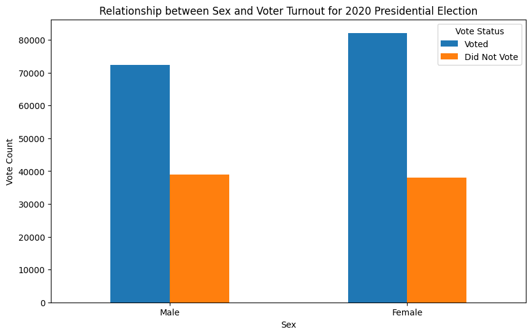

```python
contingency_table.plot(kind='bar', figsize=(10, 6))
plt.title('Relationship between Sex and Voter Turnout for 2020 Presidential Election')
plt.xlabel('Sex')
plt.ylabel('Vote Count')
plt.legend(title='Vote Status')
plt.xticks(rotation=0)
plt.show()
```

**Conclusion**: Since we have an extremely low p-value which is much less than the conventional alpha level of 0.05, we reject the null hypothesis. This indicates strong evidence of a significant relationship between sex and voter turnout in the dataset.

The dataset from the U.S. Census Bureau’s Table 4b contains demographic information related to voting and registration, specifically from the November 2020 election.\ We are trying to analyze the relationship between sex and voter turnout rates. In the context of your analysis of male and female voter turnout, there might be an over-representation of certain demographic groups (e.g., Whites or non-Hispanics) compared to others (e.g., Hispanics or Black). This can affect the overall turnout rates and skew the analysis.\ Features such as Total Registered and Total Voted are likely correlated. Higher registration rates typically lead to higher voting rates. Therefore, the Chi-squared test shows a significant difference in voter turnout between males and females.

# **D: ML Algorithm Design/Development**

### *Introduction and Problem Formulation*

In this section, we delve into the design and development of machine learning algorithms. Our primary focus is on predicting voter turnout in the upcoming election for 2024, a crucial factor in understanding electoral outcomes. To achieve this, we explore regression techniques, which are well-suited for predicting continuous target variables like voter turnout percentages.

We framed the problem of predicting voter turnout as a regression task. Specifically, we aimed to predict the total number of votes cast in a given presidential election based on historical trends and data. Given the continuous nature of the target variable (total votes), regression techniques were the natural choice for this task.

```python
voter_turnout_1980_df = pd.read_csv('/content/drive/MyDrive/320_project_data/ml_csv_files/voter_turnout_1980.csv')
voter_turnout_1984_df = pd.read_csv('/content/drive/MyDrive/320_project_data/ml_csv_files/voter_turnout_1984.csv')
voter_turnout_1988_df = pd.read_csv('/content/drive/MyDrive/320_project_data/ml_csv_files/voter_turnout_1988.csv')
voter_turnout_1992_df = pd.read_csv('/content/drive/MyDrive/320_project_data/ml_csv_files/voter_turnout_1992.csv')
voter_turnout_1996_df = pd.read_csv('/content/drive/MyDrive/320_project_data/ml_csv_files/voter_turnout_1996.csv')
voter_turnout_2000_df = pd.read_csv('/content/drive/MyDrive/320_project_data/ml_csv_files/voter_turnout_2000.csv')
voter_turnout_2004_df = pd.read_csv('/content/drive/MyDrive/320_project_data/ml_csv_files/voter_turnout_2004.csv')
voter_turnout_2008_df = pd.read_csv('/content/drive/MyDrive/320_project_data/ml_csv_files/voter_turnout_2008.csv')
voter_turnout_2012_df = pd.read_csv('/content/drive/MyDrive/320_project_data/ml_csv_files/voter_turnout_2012.csv')
voter_turnout_2016_df = pd.read_csv('/content/drive/MyDrive/320_project_data/ml_csv_files/voter_turnout_2016.csv')
voter_turnout_2020_df = pd.read_csv('/content/drive/MyDrive/320_project_data/ml_csv_files/voter_turnout_2020.csv')
print("Sample Voter Turnout Data for 2020")
print("\n")
voter_turnout_2020_df.head()
```

```
Sample Voter Turnout Data for 2020
```

|  | STATE | TOTAL VOTES | Votes_D | %_D | EV | Votes_R | %_R | EV.1 | Votes_L | %_L | EV.2 |
| --- | --- | --- | --- | --- | --- | --- | --- | --- | --- | --- | --- |
| 0 | Alabama | 2,323,282 | 849,624 | 36.57% | NaN | 1,441,170 | 62.03% | 9.0 | 32,488 | 1.40% | NaN |
| 1 | Alaska | 359,530 | 153,778 | 42.77% | NaN | 189,951 | 52.83% | 3.0 | 15,801 | 4.39% | NaN |
| 2 | Arizona | 3,387,326 | 1,672,143 | 49.36% | 11.0 | 1,661,686 | 49.06% | NaN | 53,497 | 1.58% | NaN |
| 3 | Arkansas | 1,219,069 | 423,932 | 34.78% | NaN | 760,647 | 62.40% | 6.0 | 34,490 | 2.83% | NaN |
| 4 | California | 17,500,881 | 11,110,250 | 63.48% | 55.0 | 6,006,429 | 34.32% | NaN | 384,202 | 2.20% | NaN |

## **Regression Techniques: A Deep Dive**

We initially considered various regression models for our prediction task, including linear regression, polynomial regression, and potentially more complex models like support vector regression or decision tree regression. We decided to start with linear regression due to its simplicity and interpretability. It also served as a baseline for comparison with more complex models.

We analyzed historical voter turnout data from 1980 to 2020 for three key aspects:

*Total Democratic Votes*: Using linear regression to predict total democratic votes based on election year, the resulting R-squared (R^2) value was 0.939. This indicates that the linear model reasonably explained the variance in total Democratic votes over time. We explored a third-degree polynomial regression for comparison, which yielded a higher R^2 value of 0.946, suggesting a potentially better fit. However, we maintained linear regression for its simplicity.

*Total Republican Votes:* Similarly, we applied linear regression to predict total Republican votes using election year as a predictor. The R^2 value was 0.6112, highlighting a linear relationship between year and Republican votes. We also experimented with Lasso Regression, yielding the same R^2 value of 0.6112. The advantage of Lasso Regression seems to take effect with higher dimensionality, so linear regression still seemed the best fit for the data here.

*Total Presidential Election Votes*: Finally, we applied linear and polynomial regression to predict total votes cast in presidential elections from 1980 to 2020. Linear regression achieved an R^2 of 0.91, while a second-degree polynomial model had a higher R^2 of 0.95. These R^2 values and visualizations suggested that linear and second-degree polynomial regression models could provide good predictions for total voter turnout. For our primary analysis, we opted for linear regression for overall total voter prediction.

# **Total democratic votes over the years**

```
R-squared value: 0.939
Predicted Democratic votes for 2024 (in millions): 80.41 million
```

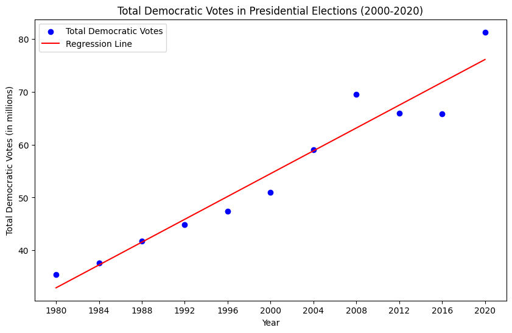

```
Polynomial Regression R-squared value: 0.946
Predicted Democratic votes for 2024 (in millions) using Polynomial Regression: 82.61 million
```

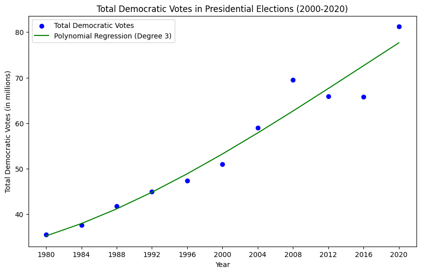

```python
import numpy as np
import matplotlib.pyplot as plt
from sklearn.linear_model import LinearRegression
from sklearn.metrics import r2_score
from sklearn.preprocessing import PolynomialFeatures
from sklearn.pipeline import make_pipeline

years = np.array([1980, 1984, 1988, 1992, 1996, 2000, 2004, 2008, 2012, 2016, 2020]).reshape(-1, 1)  # Reshape for sklearn
democratic_votes_by_year = [
    voter_turnout_1980_df.iloc[-1][voter_turnout_1980_df.columns.get_loc("Votes_D")],
    voter_turnout_1984_df.iloc[-1][voter_turnout_1984_df.columns.get_loc("Votes_D")],
    voter_turnout_1988_df.iloc[-1][voter_turnout_1988_df.columns.get_loc("Votes_D")],
    voter_turnout_1992_df.iloc[-1][voter_turnout_1992_df.columns.get_loc("Votes_D")],
    voter_turnout_1996_df.iloc[-1][voter_turnout_1996_df.columns.get_loc("Votes_D")],
    voter_turnout_2000_df.iloc[-1][voter_turnout_2000_df.columns.get_loc("Votes_D")],
    voter_turnout_2004_df.iloc[-1][voter_turnout_2004_df.columns.get_loc("Votes_D")],
    voter_turnout_2008_df.iloc[-1][voter_turnout_2008_df.columns.get_loc("Votes_D")],
    voter_turnout_2012_df.iloc[-1][voter_turnout_2012_df.columns.get_loc("Votes_D")],
    voter_turnout_2016_df.iloc[-1][voter_turnout_2016_df.columns.get_loc("Votes_D")],
    voter_turnout_2020_df.iloc[-1][voter_turnout_2020_df.columns.get_loc("Votes_D")]
]

democratic_votes_by_year = [int(str(v).replace(',', '')) for v in democratic_votes_by_year]
democratic_votes_by_year_in_millions = np.array([v / 1_000_000 for v in democratic_votes_by_year])

model = LinearRegression()
model.fit(years, democratic_votes_by_year_in_millions)

#linear model
predictions = model.predict(years)
r_squared = r2_score(democratic_votes_by_year_in_millions, predictions)
predicted_2024 = model.predict([[2024]])[0]

#print r-squared value and 2024 prediction for linear model
print(f"R-squared value: {r_squared:.3f}")
print(f"Predicted Democratic votes for 2024 (in millions): {predicted_2024:.2f} million")

plt.figure(figsize=(10, 6))
plt.scatter(years, democratic_votes_by_year_in_millions, color='blue', label="Total Democratic Votes")
plt.plot(years, predictions, color='red', linestyle='-', label="Regression Line")
plt.xlabel('Year')
plt.ylabel('Total Democratic Votes (in millions)')
plt.title('Total Democratic Votes in Presidential Elections (2000-2020)')
plt.xticks(years.flatten())
plt.legend()
plt.show()


#third degree polynomial regression as comparison
degree = 3
poly_model = make_pipeline(PolynomialFeatures(degree), LinearRegression())
poly_model.fit(years, democratic_votes_by_year_in_millions)

poly_predictions = poly_model.predict(years)
poly_r_squared = r2_score(democratic_votes_by_year_in_millions, poly_predictions)
predicted_2024_poly = poly_model.predict([[2024]])[0]

# Print R-squared and 2024 prediction for polynomial regression
print(f"Polynomial Regression R-squared value: {poly_r_squared:.3f}")
print(f"Predicted Democratic votes for 2024 (in millions) using Polynomial Regression: {predicted_2024_poly:.2f} million")

plt.figure(figsize=(10, 6))
plt.scatter(years, democratic_votes_by_year_in_millions, color='blue', label="Total Democratic Votes")
plt.plot(years, poly_predictions, color='green', linestyle='-', label=f"Polynomial Regression (Degree {degree})")
plt.xlabel('Year')
plt.ylabel('Total Democratic Votes (in millions)')
plt.title('Total Democratic Votes in Presidential Elections (2000-2020)')
plt.xticks(years.flatten())
plt.legend()
plt.show()
```

# **Total Republican Votes over the Years**

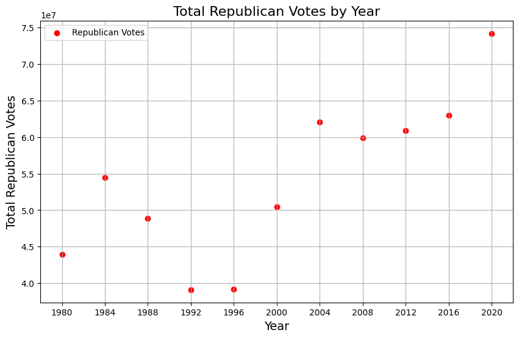

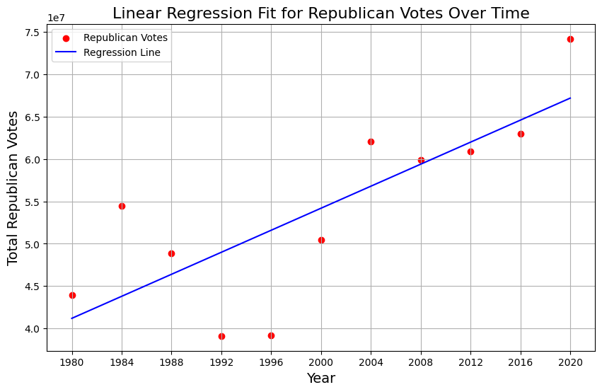

```
R^2 Score: 0.6113
Predicted Republican Votes for 2024: 69,800,568
```

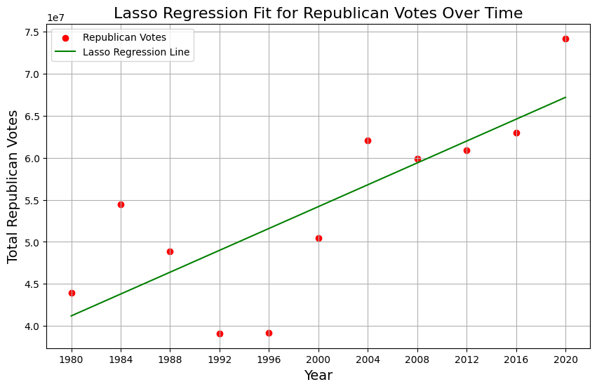

```
Lasso Regression R^2 Score: 0.6113
```

```python
from sklearn.metrics import r2_score
# Extract the total votes for each year
years = [1980, 1984, 1988, 1992, 1996, 2000, 2004, 2008, 2012, 2016, 2020]
republican_votes_by_year = [
    voter_turnout_1980_df.iloc[-1][voter_turnout_1980_df.columns.get_loc("Votes_R")],
    voter_turnout_1984_df.iloc[-1][voter_turnout_1984_df.columns.get_loc("Votes_R")],
    voter_turnout_1988_df.iloc[-1][voter_turnout_1988_df.columns.get_loc("Votes_R")],
    voter_turnout_1992_df.iloc[-1][voter_turnout_1992_df.columns.get_loc("Votes_R")],
    voter_turnout_1996_df.iloc[-1][voter_turnout_1996_df.columns.get_loc("Votes_R")],
    voter_turnout_2000_df.iloc[-1][voter_turnout_2000_df.columns.get_loc("Votes_R")],
    voter_turnout_2004_df.iloc[-1][voter_turnout_2004_df.columns.get_loc("Votes_R")],
    voter_turnout_2008_df.iloc[-1][voter_turnout_2008_df.columns.get_loc("Votes_R")],
    voter_turnout_2012_df.iloc[-1][voter_turnout_2012_df.columns.get_loc("Votes_R")],
    voter_turnout_2016_df.iloc[-1][voter_turnout_2016_df.columns.get_loc("Votes_R")],
    voter_turnout_2020_df.iloc[-1][voter_turnout_2020_df.columns.get_loc("Votes_R")]]

republican_votes_by_year = [int(str(v).replace(',', '')) for v in republican_votes_by_year]


plt.figure(figsize=(10, 6))
plt.scatter(years, republican_votes_by_year, color='red', label='Republican Votes')

# Add titles and labels
plt.title('Total Republican Votes by Year', fontsize=16)
plt.xlabel('Year', fontsize=14)
plt.ylabel('Total Republican Votes', fontsize=14)
plt.xticks(years)  # Set x-axis ticks to the years
plt.grid(True)
plt.legend()

# Show the plot
plt.show()

############################################################################################
from sklearn.linear_model import LinearRegression
import numpy as np
import matplotlib.pyplot as plt

# Prepare the data
years = np.array([1980, 1984, 1988, 1992, 1996, 2000, 2004, 2008, 2012, 2016, 2020]).reshape(-1, 1)  # Reshape for sklearn
republican_votes = np.array([int(str(v).replace(',', '')) for v in republican_votes_by_year])  # Clean and convert to integers

# Fit the linear regression model
model = LinearRegression()
model.fit(years, republican_votes)

# Predict values for the regression line
predicted_votes = model.predict(years)

# Create the plot
plt.figure(figsize=(10, 6))
plt.scatter(years, republican_votes, color='red', label='Republican Votes')  # Original data
plt.plot(years, predicted_votes, color='blue', label='Regression Line')  # Regression line

# Add titles and labels
plt.title('Linear Regression Fit for Republican Votes Over Time', fontsize=16)
plt.xlabel('Year', fontsize=14)
plt.ylabel('Total Republican Votes', fontsize=14)
plt.xticks(years.flatten())  # Set x-axis ticks to the years
plt.grid(True)
plt.legend()

# Show the plot
plt.show()

r2 = r2_score(republican_votes, predicted_votes)
print(f"R^2 Score: {r2:.4f}")

year_2024 = np.array([[2024]])  # Year 2024 as a 2D array
prediction_2024 = model.predict(year_2024)
print(f"Predicted Republican Votes for 2024: {int(prediction_2024[0]):,}")

############################################################################################
from sklearn.linear_model import Lasso

# Fit the Lasso regression model
lasso_model = Lasso(alpha=0.1)  # You can adjust the alpha parameter to control regularization strength
lasso_model.fit(years, republican_votes)

# Predict values for the Lasso regression line
lasso_predicted_votes = lasso_model.predict(years)

# Plot the Lasso regression line
plt.figure(figsize=(10, 6))
plt.scatter(years, republican_votes, color='red', label='Republican Votes')  # Original data
plt.plot(years, lasso_predicted_votes, color='green', label='Lasso Regression Line')  # Lasso regression line

# Add titles and labels
plt.title('Lasso Regression Fit for Republican Votes Over Time', fontsize=16)
plt.xlabel('Year', fontsize=14)
plt.ylabel('Total Republican Votes', fontsize=14)
plt.xticks(years.flatten())  # Set x-axis ticks to the years
plt.grid(True)
plt.legend()

# Show the plot
plt.show()

# Calculate R^2 score for Lasso Regression
lasso_r2 = r2_score(republican_votes, lasso_predicted_votes)
print(f"Lasso Regression R^2 Score: {lasso_r2:.4f}")
```

# **Total Votes over the Years**

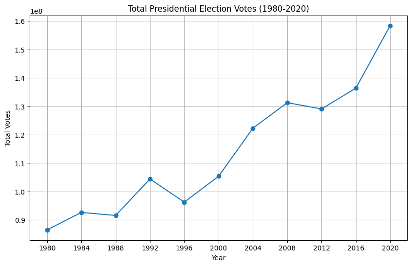

```python
import matplotlib.pyplot as plt

# Extract the total votes for each year
years = [1980, 1984, 1988, 1992, 1996, 2000, 2004, 2008, 2012, 2016, 2020]
total_votes = [voter_turnout_1980_df.iloc[-1, 1],  # Second column, last row
               voter_turnout_1984_df.iloc[-1, 1],
               voter_turnout_1988_df.iloc[-1, 1],
               voter_turnout_1992_df.iloc[-1, 1],
               voter_turnout_1996_df.iloc[-1, 1],
    voter_turnout_2000_df.iloc[-1, 1],  # Second column, last row
               voter_turnout_2004_df.iloc[-1, 1],
               voter_turnout_2008_df.iloc[-1, 1],
               voter_turnout_2012_df.iloc[-1, 1],
               voter_turnout_2016_df.iloc[-1, 1],
               voter_turnout_2020_df.iloc[-1, 1]]

total_votes = [int(str(v).replace(',', '')) for v in total_votes]

# Create the plot
plt.figure(figsize=(10, 6))  # Adjust figure size if needed
plt.plot(years, total_votes, marker='o', linestyle='-')

# Customize the plot
plt.title('Total Presidential Election Votes (1980-2020)')
plt.xlabel('Year')
plt.ylabel('Total Votes')
plt.grid(True)

plt.xticks(years, [int(year) for year in years])

# Display the plot
plt.show()
```

```
Predicted Total Votes for 2024: 153,643,854
```

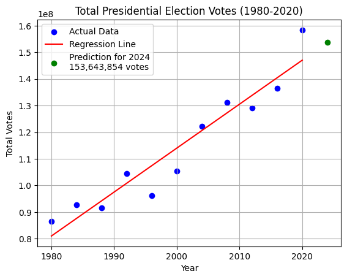

```
Predicted Total Votes for 2024: 153,643,854
R^2 Score: 0.91
Mean Squared Error (MSE): 41914372787642.15
Mean Absolute Error (MAE): 5674563.46
```

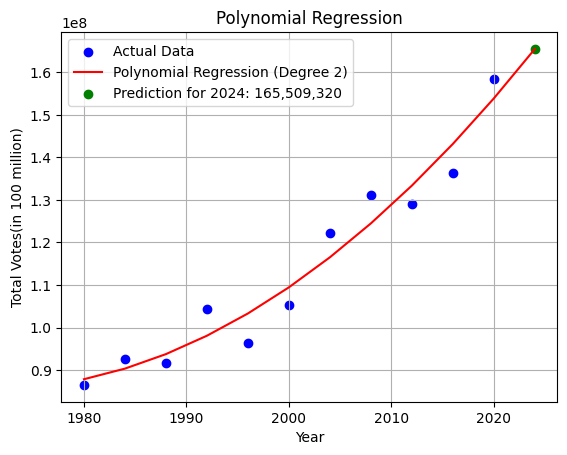

```
Predicted Total Votes for 2024: 165,509,320
R^2 Score: 0.95
Mean Squared Error (MSE): 25669457463965.73
Mean Absolute Error (MAE): 4673273.13
```

```python
import numpy as np
from sklearn.linear_model import LinearRegression
from sklearn.preprocessing import PolynomialFeatures
import matplotlib.pyplot as plt
from sklearn.metrics import r2_score, mean_squared_error, mean_absolute_error

# Years as the independent variable (X)
years = np.array([1980, 1984, 1988, 1992, 1996, 2000, 2004, 2008, 2012, 2016, 2020]).reshape(-1, 1)

# Total votes as the dependent variable (y)
total_votes = np.array(total_votes)  # total_votes should already be defined

model = LinearRegression()
model.fit(years, total_votes)

year_2024 = np.array([[2024]])
predicted_votes_2024 = model.predict(year_2024)
print(f"Predicted Total Votes for 2024: {int(predicted_votes_2024[0]):,}")

# Predictions for the existing data points
predicted_votes = model.predict(years)

# Calculate metrics
r2 = r2_score(total_votes, predicted_votes)
mse = mean_squared_error(total_votes, predicted_votes)
mae = mean_absolute_error(total_votes, predicted_votes)

# Plot the data and regression line
plt.scatter(years, total_votes, color='blue', label='Actual Data')
plt.plot(years, predicted_votes, color='red', label='Regression Line')
plt.scatter(year_2024, predicted_votes_2024, color='green', label=f'Prediction for 2024\n{int(predicted_votes_2024[0]):,} votes')
plt.xlabel('Year')
plt.ylabel('Total Votes')
plt.title('Total Presidential Election Votes (1980-2020)')
plt.legend()
plt.grid(True)
plt.show()

# Display metrics
print(f"Predicted Total Votes for 2024: {int(predicted_votes_2024[0]):,}")
print(f"R^2 Score: {r2:.2f}")
print(f"Mean Squared Error (MSE): {mse:.2f}")
print(f"Mean Absolute Error (MAE): {mae:.2f}")

# Define years and total_votes
years = np.array([1980, 1984, 1988, 1992, 1996, 2000, 2004, 2008, 2012, 2016, 2020]).reshape(-1, 1)
total_votes = np.array(total_votes)  # total_votes should already be defined

# Apply polynomial features
degree = 2  # You can experiment with different degrees
poly = PolynomialFeatures(degree=degree)
years_poly = poly.fit_transform(years)

# Fit polynomial regression model
model = LinearRegression()
model.fit(years_poly, total_votes)

predicted_votes = model.predict(years_poly)


# Calculate metrics
r2 = r2_score(total_votes, predicted_votes)
mse = mean_squared_error(total_votes, predicted_votes)
mae = mean_absolute_error(total_votes, predicted_votes)

# Predict for existing years and 2024
years_extended = np.append(years, [[2024]]).reshape(-1, 1)
years_poly_extended = poly.transform(years_extended)
predicted_votes = model.predict(years_poly_extended)

# Visualize
plt.scatter(years, total_votes, color='blue', label='Actual Data')
plt.plot(years_extended, predicted_votes, color='red', label=f'Polynomial Regression (Degree {degree})')
plt.scatter([[2024]], [predicted_votes[-1]], color='green', label=f'Prediction for 2024: {int(predicted_votes[-1]):,}')
plt.xlabel('Year')
plt.ylabel('Total Votes(in 100 million)')
plt.title('Polynomial Regression')
plt.legend()
plt.grid(True)
plt.show()

# Predicted value for 2024
print(f"Predicted Total Votes for 2024: {int(predicted_votes[-1]):,}")
print(f"R^2 Score: {r2:.2f}")
print(f"Mean Squared Error (MSE): {mse:.2f}")
print(f"Mean Absolute Error (MAE): {mae:.2f}")
```

# Linear and Polynomial Regression Models Tested

1. Linear Regression Model:

The general form of the linear regression model we used is:

`y = mx + c`

where:

`y` is the dependent variable (e.g., total votes)

`x` is the independent variable (e.g., election year)

`m` is the slope

`c` is the y-intercept

We applied this model to predict voter turnout (total votes, democratic votes, and republican votes) based on election year.

1. Polynomial Regression Model:

The general form of the polynomial regression model we used is:

`y = a_n * x^n + a_(n-1) * x^(n-1) + ... + a_1 * x + a_0`

where:

`y` is the dependent variable

`x` is the independent variable

`a_n, a_(n-1), ..., a_1, a_0` are coefficients

`n` is the degree of the polynomial

We tested polynomial regression with different degrees (e.g., 2nd and 3rd degree) to see if it could provide a better fit compared to linear regression.

## Rationale for Choosing Linear Regression

While polynomial regression can sometimes provide a better fit to the data, especially when there are non-linear relationships between variables, we opted for linear regression for the following reasons:

1. Simplicity and Interpretability: Linear models
- straightforward to understand
- coefficients directly represent the impact of predictor variable on the response variable
1. Avoiding Overfitting
- As degree increases, model becomes more complex - can overfit
- May perform poorly on new data
- as the degree increases, the more unnatural the model seems to move to fit the data
1. Generalization
- Linear models are more likely to generalize well to new data
- Makes it important for making reliable predictions for future elections

Thus, while acknowledging the potential for better in-sample fit with polynomial models, we prioritized simplicity, interpretability, and generalization, leading us to choose linear regression as our primary model for voter turnout prediction. This choice helps to ensure that the model works reliably on data outside the scope of the data it was initially fed.

# **E: ML Algorithm Training and Test Data Analysis**

## *Swing State Analysis using Linear, Polynomial, and Weighted Regression*

Building upon our selection of linear regression as the primary model, we applied it to analyze and predict voter turnout trends in swing states. We used the 2024 definition of swing states, which includes:

- Arizona
- Georgia
- Michigan
- Nevada
- North Carolina
- Pennsylvania
- Wisconsin

For this analysis, we focused on predicting the Democratic win margin in each swing state over time. The Democratic win margin is calculated as the difference between the percentage of votes for the Democratic candidate and the percentage of votes for the Republican candidate.

**Data Preparation and Model Training**

We compiled historical data for presidential elections from 1980 to 2020 for each swing state. This data included the total votes cast, votes for the Democratic and Republican candidates, and the percentage of votes for each candidate.

We then trained a separate linear regression model for each swing state, using the election year as the independent variable (predictor) and the Democratic win margin as the dependent variable (response). This allowed us to model how the Democratic win margin has changed over time in each state.

```python
test_states = ["Arizona", "Georgia", "Michigan", "Nevada", "North Carolina", "Pennsylvania", "Wisconsin", "California", "New York", "Texas"]
swing_states_1980_df = voter_turnout_1980_df[voter_turnout_1980_df['STATE'].isin(test_states)]
swing_states_1984_df = voter_turnout_1984_df[voter_turnout_1984_df['STATE'].isin(test_states)]
swing_states_1988_df = voter_turnout_1988_df[voter_turnout_1988_df['STATE'].isin(test_states)]
swing_states_1992_df = voter_turnout_1992_df[voter_turnout_1992_df['STATE'].isin(test_states)]
swing_states_1996_df = voter_turnout_1996_df[voter_turnout_1996_df['STATE'].isin(test_states)]
swing_states_2000_df = voter_turnout_2000_df[voter_turnout_2000_df['STATE'].isin(test_states)]
swing_states_2004_df = voter_turnout_2004_df[voter_turnout_2004_df['STATE'].isin(test_states)]
swing_states_2008_df = voter_turnout_2008_df[voter_turnout_2008_df['STATE'].isin(test_states)]
swing_states_2012_df = voter_turnout_2012_df[voter_turnout_2012_df['STATE'].isin(test_states)]
swing_states_2016_df = voter_turnout_2016_df[voter_turnout_2016_df['STATE'].isin(test_states)]
swing_states_2020_df = voter_turnout_2020_df[voter_turnout_2020_df['STATE'].isin(test_states)]

def calculate_dem_win_margin(df):
    # Make a copy of the DataFrame to avoid the warning
    df = df.copy()

    # Ensure the '%' columns are strings, then clean and convert to numeric
    df.loc[:, '%_D'] = df['%_D'].astype(str).str.replace('%', '').astype(float)  # Democratic margin
    df.loc[:, '%_R'] = df['%_R'].astype(str).str.replace('%', '').astype(float)  # Republican margin

    # Compute the Democratic win margin and add as a new column
    df.loc[:, 'Dem_Win_Margin'] = df['%_D'] - df['%_R']
    return df

# Apply the function to each swing state DataFrame
swing_states_1980_df = calculate_dem_win_margin(swing_states_1980_df)
swing_states_1984_df = calculate_dem_win_margin(swing_states_1984_df)
swing_states_1988_df = calculate_dem_win_margin(swing_states_1988_df)
swing_states_1992_df = calculate_dem_win_margin(swing_states_1992_df)
swing_states_1996_df = calculate_dem_win_margin(swing_states_1996_df)
swing_states_2000_df = calculate_dem_win_margin(swing_states_2000_df)
swing_states_2004_df = calculate_dem_win_margin(swing_states_2004_df)
swing_states_2008_df = calculate_dem_win_margin(swing_states_2008_df)
swing_states_2012_df = calculate_dem_win_margin(swing_states_2012_df)
swing_states_2016_df = calculate_dem_win_margin(swing_states_2016_df)
swing_states_2020_df = calculate_dem_win_margin(swing_states_2020_df)

swing_states_1980_df.rename(columns={'T. VOTES' : 'TOTAL VOTES'}, inplace=True)
swing_states_1992_df.rename(columns={'T. VOTES' : 'TOTAL VOTES'}, inplace=True)
swing_states_1996_df.rename(columns={'T. VOTES' : 'TOTAL VOTES'}, inplace=True)
```

## **Linear and Polynomial Regression for Swing and Non-Swing States**

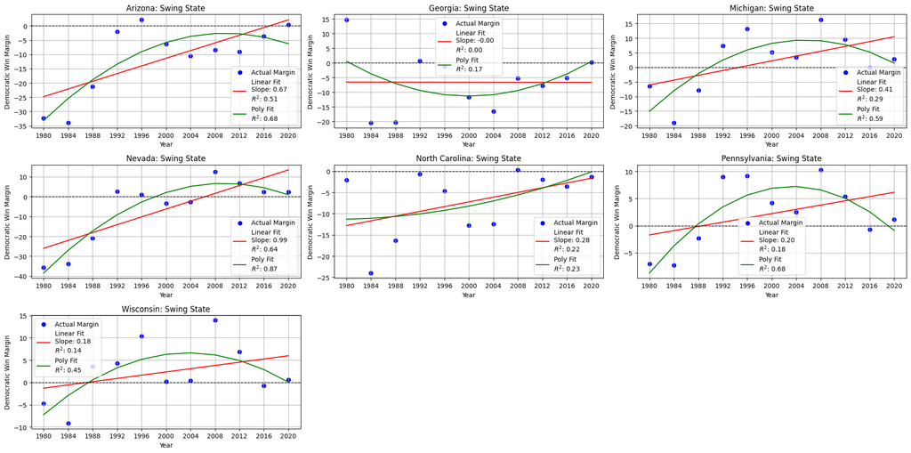

```
Swing State Predictions for 2024:
Arizona - Linear: 4.75, Polynomial: -9.66
Georgia - Linear: -6.67, Polynomial: 5.62
Michigan - Linear: 12.13, Polynomial: -3.53
Nevada - Linear: 17.39, Polynomial: -4.23
North Carolina - Linear: -0.55, Polynomial: 2.04
Pennsylvania - Linear: 6.95, Polynomial: -5.27
Wisconsin - Linear: 6.69, Polynomial: -3.57
```

```python
import pandas as pd
import numpy as np
from sklearn.linear_model import LinearRegression
from sklearn.preprocessing import PolynomialFeatures
import matplotlib.pyplot as plt

# Combine all swing state DataFrames into one with the year added
datasets = [
    (swing_states_1980_df, 1980),
    (swing_states_1984_df, 1984),
    (swing_states_1988_df, 1988),
    (swing_states_1992_df, 1992),
    (swing_states_1996_df, 1996),
    (swing_states_2000_df, 2000),
    (swing_states_2004_df, 2004),
    (swing_states_2008_df, 2008),
    (swing_states_2012_df, 2012),
    (swing_states_2016_df, 2016),
    (swing_states_2020_df, 2020),
]

# Add year and combine into one DataFrame
for df, year in datasets:
    df['Year'] = year

swing_states_combined_df = pd.concat([df for df, _ in datasets])

# List of swing states and non-swing states
swing_states = ["Arizona", "Georgia", "Michigan", "Nevada", "North Carolina", "Pennsylvania", "Wisconsin"]
non_swing_states = ["California", "New York", "Texas"]

# Helper function for polynomial regression
def polynomial_regression(X, y, degree, weights=None):
    poly_features = PolynomialFeatures(degree=degree)
    X_poly = poly_features.fit_transform(X)

    poly_model = LinearRegression()

    if weights is not None:
        poly_model.fit(X_poly, y, sample_weight=weights)
    else:
        poly_model.fit(X_poly, y)

    y_pred_poly = poly_model.predict(X_poly)
    return y_pred_poly, poly_model, poly_features

### Swing States ###
plt.figure(figsize=(20, 10))
predictions_2024_swing = {}

for i, state in enumerate(swing_states, 1):
    state_data = swing_states_combined_df[swing_states_combined_df['STATE'] == state]
    state_data = state_data.sort_values('Year')

    X = state_data['Year'].values.reshape(-1, 1)
    y = state_data['Dem_Win_Margin'].values

    #Linear regression
    model = LinearRegression()
    model.fit(X, y)
    y_pred = model.predict(X)
    r_squared = model.score(X, y)
    linear_prediction_2024 = model.predict([[2024]])[0]


    # Polynomial regression
    degree = 2
    y_pred_poly, poly_model, poly_features = polynomial_regression(X, y, degree)
    r_squared_poly = poly_model.score(poly_features.transform(X), y)
    poly_prediction_2024 = poly_model.predict(poly_features.transform([[2024]]))[0]


    # Store both predictions
    predictions_2024_swing[state] = {
        "Linear": linear_prediction_2024,
        "Polynomial": poly_prediction_2024
    }

    # Plot
    plt.subplot(3, 3, i)
    plt.scatter(X, y, color='blue', label='Actual Margin')
    plt.plot(X, y_pred, color='red', label=f'Linear Fit\nSlope: {model.coef_[0]:.2f}\n$R^2$: {r_squared:.2f}')
    plt.plot(X, y_pred_poly, color='green', label=f'Poly Fit\n$R^2$: {r_squared_poly:.2f}')
    plt.title(f'{state}: Swing State')
    plt.xlabel('Year')
    plt.ylabel('Democratic Win Margin')
    plt.axhline(0, color='black', linestyle='--', linewidth=1)
    plt.xticks(np.arange(1980, 2021, 4))
    plt.legend()
    plt.grid(True)

plt.tight_layout()
plt.show()

# Print Swing State Predictions
print("Swing State Predictions for 2024:")
for state, predictions in predictions_2024_swing.items():
    print(f"{state} - Linear: {predictions['Linear']:.2f}, Polynomial: {predictions['Polynomial']:.2f}")
```